# Задача для супермаркета «Хлеб-Соль»

### Задача:

Сетевой супермаркет «Хлеб-Соль» внедряет систему компьютерного зрения для обработки фотографий покупателей.

Фотофиксация в прикассовой зоне поможет определять возраст клиентов, чтобы:

- Анализировать покупки и предлагать товары, которые могут заинтересовать покупателей этой возрастной группы;
- Контролировать добросовестность кассиров при продаже алкоголя.

Необходимо построить модель, которая по фотографии определит приблизительный возраст человека. В нашем распоряжении набор фотографий людей с указанием возраста.

Отлично если получится достичь метрику MAE меньше 7, но достаточным будет результат и меньше 8.

### Описание данных:

В папке `/datasets/faces/` содержится csv-файл labels.csv с двумя колонками file_name(имя файла) и real_age(реальный возраст), а также папка с самими изображениями `/final_files`ag`

### План работы:

**Шаг 1.** Исследовательский анализ данных.

**Шаг 2.** Подготовка данных к обучению.

**Шаг 3.** Построение и обучение модели, рассчет качества.

**Шаг 4.** Общий вывод.

### Шаг 1. Исследовательский анализ данных.

```python
import numpy as np
import matplotlib.pyplot as plt
import pandas as pd

from tensorflow.keras.models import Sequential
from tensorflow.keras.layers import Conv2D, Flatten, Dense, GlobalAveragePooling2D
from tensorflow.keras.preprocessing.image import ImageDataGenerator
from tensorflow.keras.optimizers import Adam
from tensorflow.keras.applications.resnet import ResNet50
```

```python
data = pd.read_csv('/datasets/faces/labels.csv')
```

```python
data.info
```

```
<bound method DataFrame.info of        file_name  real_age
0     000000.jpg         4
1     000001.jpg        18
2     000002.jpg        80
3     000003.jpg        50
4     000004.jpg        17
...          ...       ...
7586  007608.jpg        14
7587  007609.jpg        37
7588  007610.jpg        28
7589  007611.jpg        20
7590  007612.jpg        47

[7591 rows x 2 columns]>
```

В полученном датафрейме 7591 изображение. Посмотрим на распределение возраста:

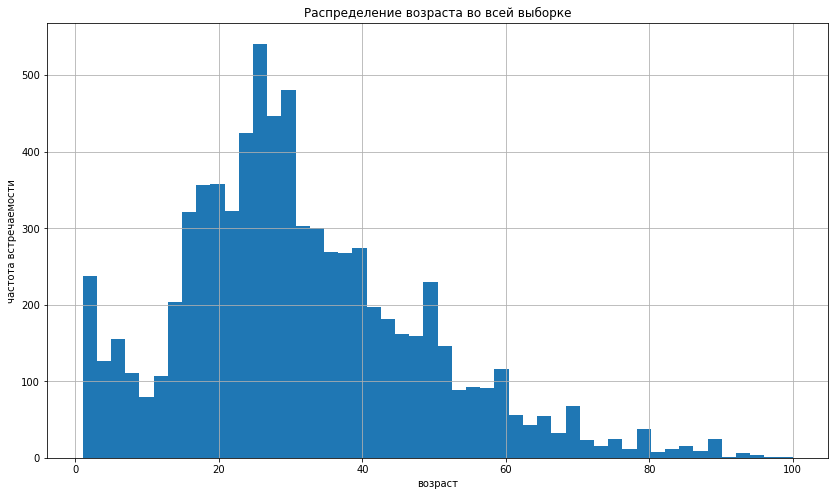

```python
plt.title('Распределение возраста во всей выборке')
plt.ylabel('частота встречаемости')
plt.xlabel('возраст')
data['real_age'].hist(figsize=(14, 8),bins = 50);
```

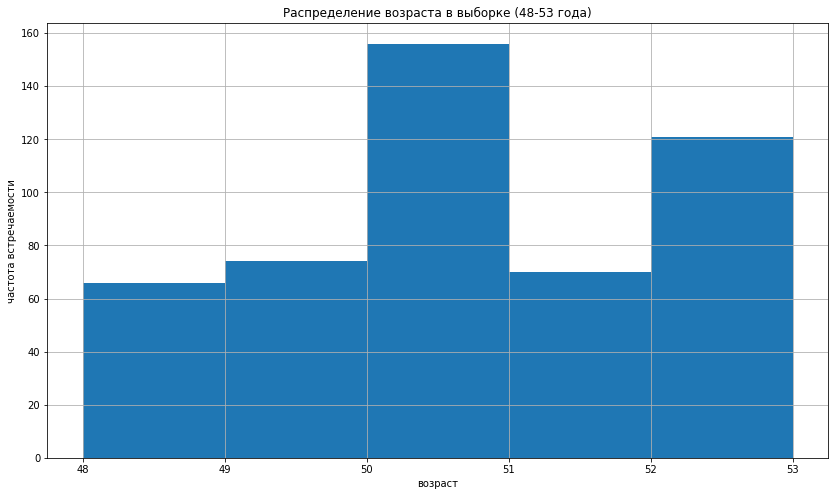

```python
plt.title('Распределение возраста в выборке (48-53 года)')
plt.ylabel('частота встречаемости')
plt.xlabel('возраст')
data['real_age'].hist(figsize=(14, 8),bins = 5, range =(48,53));
```

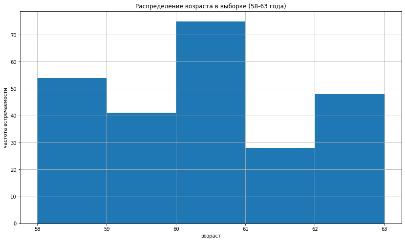

```python
plt.title('Распределение возраста в выборке (58-63 года)')
plt.ylabel('частота встречаемости')
plt.xlabel('возраст')
data['real_age'].hist(figsize=(14, 8),bins = 5, range =(58,63));
```

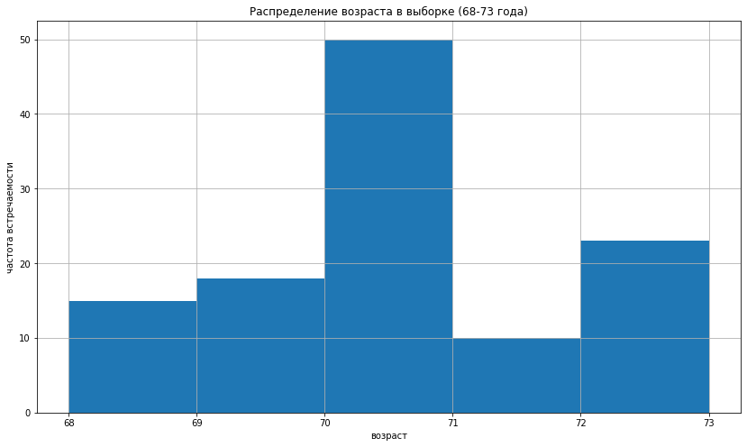

```python
plt.title('Распределение возраста в выборке (68-73 года)')
plt.ylabel('частота встречаемости')
plt.xlabel('возраст')
data['real_age'].hist(figsize=(14, 8),bins = 5, range =(68,73));
```

График распределения близок к нормальному. Но заметна некоторая бимодальность (пик около нуля и пик около 25 лет).

Чаще всего встречаются фотографии людей от 15 до 32 лет. Меньше всего людей старше 70.

Отдельные небольшие пики на графике возможно обусловлены увеличением количества фотографий в юбилейные даты из разряда 40,50,60,70..лет

Посмотрим нет ли пропущенных значений:

```python
#Процент пропущ. значений для каждого столбца датафрейма
(data.isna().mean() * 100).to_frame()
```

|  | 0 |
| --- | --- |
| file_name | 0.0 |
| real_age | 0.0 |

Пропущенных значений нет. Загрузим изображения, и взглянем на несколько из них:

```python
datagen = ImageDataGenerator(rescale=1./255)
datagen_flow = datagen.flow_from_dataframe(
        data,
        directory='/datasets/faces/final_files/',
        x_col='file_name',
        y_col='real_age',
        target_size=(224, 224),
        class_mode='raw',
        batch_size=16
    )

features, target = next(datagen_flow)
```

```
Found 7591 validated image filenames.
```

```python
features.shape
```

```
(16, 224, 224, 3)
```

Мы имеем дело с цветными изображениями, которые для обучения будут приводимы к размеру 224x224 и выгружаемы батчами по 16 штук

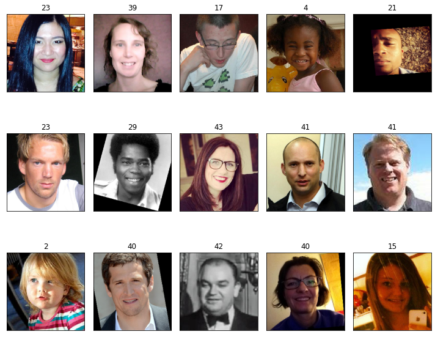

```python
# выводим 15 изображений
fig = plt.figure(figsize=(10,10))
for i in range(15):
    fig.add_subplot(3, 5, i+1)
    plt.imshow(features[i])
    #добавляем отображение возраста
    plt.title(target[i])
    # для компактности удаляем оси и прижимаем изображения друг к другу
    plt.xticks([])
    plt.yticks([])
    plt.tight_layout()
```

На первый взгляд можно заметить что в выборке у нас изображения разного качества и яркости. Также присутствует немало изображений с поворотами. Разметка похожа на правду.

**Промежуточный вывод**

График распределения близок к нормальному. Чаще всего встречаются фотографии людей от 15 до 32 лет. Меньше всего людей старше 70.

- Для повышения качества обучения стоит добавить в тренировочную выборку изображения с поворотами, различной яркостью и горизонтальным флипом.
- Учитывая распределение возрастов в представленной выборке, модель будет более точно определять возраст младенцев (1-2года), людей в возрасте от 16-32 лет и 50 лет.

### Шаг 2. Подготовка данных к обучению.

- Будем использовать динамическую загрузку данных с помощью ImageDataGenerator из библиотеки Keras.
- Разделим данные на тренировочную и тестовую выборку в соотношении 3:1
- "Раздуем" немного обучающую выборку, сгенерировав из существующих изображения с случайными поворотами на 20 градусов, горизонтальными флипами, и разной яркостью:

```
def load_train(path):
    """
    Функция для загрузки обучающей выборки:
    На вход принимает путь к папке с таблицей и папкой изображений
    На выходе возвращает загрузчик данных обучающей выборки
    """
    data = pd.read_csv(path +'labels.csv')

    datagen = ImageDataGenerator(
        validation_split=0.25,
        rescale=1./255,
        horizontal_flip=True,
        rotation_range=20,
        brightness_range=(0.8, 1.0)
    )

    train_datagen_flow = datagen.flow_from_dataframe(
            data,
            directory=path + 'final_files',
            x_col='file_name',
            y_col='real_age',
            target_size=(224, 224),
            class_mode='raw',
            batch_size=16,
            shuffle=True,
            subset='training',
            seed=12345
        )

    return train_datagen_flow

def load_test(path):
    """
    Функция для загрузки тестовой выборки:
     На вход принимает путь к папке с таблицей и папкой изображений
    На выходе возвращает загрузчик данных тестовой выборки
    """
    data = pd.read_csv(path +'labels.csv')

    datagen = ImageDataGenerator(
        validation_split=0.25,
        rescale=1./255
    )

    test_datagen_flow = datagen.flow_from_dataframe(
            data,
            directory=path + 'final_files',
            x_col='file_name',
            y_col='real_age',
            target_size=(224, 224),
            class_mode='raw',
            batch_size=16,
            shuffle=False,
            subset='validation',
            seed=12345
        )

    return test_datagen_flow
```

### Шаг 3. Построение и обучение модели, рассчет качества.

Напишем функции для создания модели и ее обучения.

В качестве функции потерь будем использовать MAE.

Так как перед нами задача регрессии, в конце сети останется только один нейрон, для которого применим функцию активации `relu` - она не изменит наших положительных прогнозов, а отрицательные приведет к нулю (так как возраст не может быть отрицательным).

```
def create_model(input_shape):
    """
    Функция создает модель для нейронной сети
    На вход получает размер данных в первом слое - input_shape
    На выходе возвращает модель
    """
    optimizer = Adam(learning_rate = 0.0001)

    backbone = ResNet50(input_shape=input_shape,
                        weights='imagenet',
                        include_top=False)

    model = Sequential()
    model.add(backbone)
    model.add(GlobalAveragePooling2D())
    model.add(Dense(1, activation='relu'))

    model.compile(loss='mean_absolute_error', optimizer=optimizer, metrics=['mae'])#

    return model

def train_model(model, train_data, test_data, batch_size=None, epochs=9,
                steps_per_epoch=None, validation_steps=None):
    """
    Функция для обучения модели
    Функция получает на вход модель,
    обучающую и тестовую выборку,аргументы для метода fit().
    На выходе возвращается модель
    """

    if steps_per_epoch is None:
        steps_per_epoch = len(train_data)
    if validation_steps is None:
        validation_steps = len(test_data)

    model.fit(train_data,
              validation_data=test_data,
              batch_size=batch_size, epochs=epochs,
              steps_per_epoch=steps_per_epoch,
              validation_steps=validation_steps,
              verbose=2, shuffle=True)

    return model
```

**Шаг 2 и 3 выполнялся в отдельном GPU-тренажёре, поэтому оформлен не как ячейка с кодом, а как код в текстовой ячейке. Результаты обучения:**

```
Train for 356 steps, validate for 119 steps
Epoch 1/9
2024-01-21 13:35:21.751868: I tensorflow/stream_executor/platform/default/dso_loader.cc:44] Successfully opened dynamic library libcublas.so.10
2024-01-21 13:35:22.920103: I tensorflow/stream_executor/platform/default/dso_loader.cc:44] Successfully opened dynamic library libcudnn.so.7
356/356 - 129s - loss: 10.5769 - mae: 10.5777 - val_loss: 18.4098 - val_mae: 18.4369
Epoch 2/9
356/356 - 102s - loss: 7.9290 - mae: 7.9292 - val_loss: 9.8801 - val_mae: 9.8958
Epoch 3/9
356/356 - 105s - loss: 7.2087 - mae: 7.2093 - val_loss: 8.6014 - val_mae: 8.6094
Epoch 4/9
356/356 - 102s - loss: 6.6612 - mae: 6.6622 - val_loss: 6.7279 - val_mae: 6.7275
Epoch 5/9
356/356 - 102s - loss: 6.3220 - mae: 6.3222 - val_loss: 6.9324 - val_mae: 6.9366
Epoch 6/9
356/356 - 102s - loss: 5.9896 - mae: 5.9899 - val_loss: 7.5743 - val_mae: 7.5829
Epoch 7/9
356/356 - 102s - loss: 5.5206 - mae: 5.5210 - val_loss: 6.4938 - val_mae: 6.5006
Epoch 8/9
356/356 - 102s - loss: 5.2261 - mae: 5.2263 - val_loss: 7.9488 - val_mae: 7.9409
Epoch 9/9
356/356 - 102s - loss: 5.0932 - mae: 5.0927 - val_loss: 6.7102 - val_mae: 6.7096
WARNING:tensorflow:sample_weight modes were coerced from
  ...
    to
  ['...']
119/119 - 10s - loss: 6.7102 - mae: 6.7096
Test MAE: 6.7096
```

Лучший результат MAE на тестовой выборке 6.50 достигнут на 7 эпохе обучения. Анализируя вышеприведенный вывод обучения модели, можно сказать что удалось избежать переобучения.

### Шаг 4. Общий вывод

Целью исследования было построить и обучить модель для определения возраста клиента по фотографии.

- В качестве данных был получен датафрейм с 7591 изображением и соответсвующими возрастами. Предоставленные изображения были разного качества и яркости, также присутсвовало немало изображений с поворотами.
- Было проанализировано распредление возрастов:

График распределения близок к нормальному. Чаще всего встречаются фотографии людей от 15 до 32 лет. Меньше всего людей старше 70.

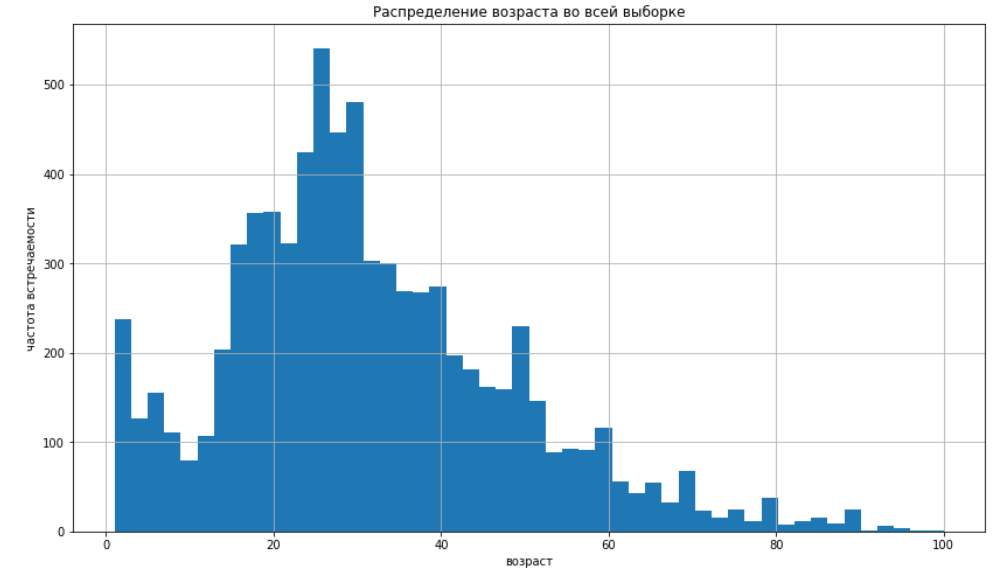

- Решаемая задача - задача регрессии. Для решения задачи использовался костяк ResNet50 и голова с полносвязным слоем в один нейрон.

- Лучший результат MAE на тестовой выборке 6.50 достигнут на 7 эпохе обучения.

Анализируя вышеприведенный вывод обучения модели, можно сказать что удалось избежать переобучения.

Для улучшения результатов модели можно поэксперементировать еще дальше с аугментацией, попробовать изменять гиперпараметры модели, а также было немало фотографий с рамками (которые не просто от поворота появились) можно убрать их и посмотреть на результат.

### Итог и рекомендации:

По итогу работы была построена и обучена модель, с указанными выше характеристиками для определения возраста клиента по фотографии. Модель показала отличные результаты при тестировании, и соответствует требуемому качеству (MAE<8).

Мы надеемся, что данная модель поможет увеличить выручку супермаркета и осуществлять более качественный контроль работы кассиров.